# Project 1 - Malaria

Mo Hijazi

10/12/2021

```r
# All libraries required for code.
library(ggplot2)
library(reshape2)
library(tidyr)
library(janitor)
library(packcircles)
library(viridis)
library(viridisLite)
library(maps)
library(tidyverse)
library(scales)
library(gganimate)
library(gifski)
library(dplyr)
library(gapminder)
library(ggthemes)
library(readr)
library(magick)
library(magrittr)
```

```r
knitr::opts_chunk$set(echo = TRUE)

#Loading in the csv file.
malaria <- read.csv("malaria_data_2.csv", skip = 1)
```

Cleaning up the data set:

```r
#Renaming specific countries on the data to match the world map names.
malaria$Entity[1401:1428] <- "Ivory Coast"
malaria$Entity[1345:1372] <- "Democratic Republic of the Congo"
malaria$Entity[1541:1568] <- "Democratic Republic of the Congo"
malaria$Entity[1065:1092] <- "China"
malaria$Entity[1121:1148] <- "Spain"
malaria$Entity[1681:1708] <- "China"
malaria$Entity[5209:5236] <- "China"
malaria$Entity[5293:5348] <- "China"

#Making sure the data is numeric for calculations.
malaria$Entity <- factor(malaria$Entity)
#Cleaning up the column names, removing unneeded columns, and omitting any NA values.
malaria <- clean_names(malaria)
malaria <- subset(malaria, select = -2) %>%
  na.omit(malaria)
malaria2003 <- malaria
malaria1990 <- malaria
malaria1991 <- malaria
malaria1992 <- malaria
malaria1993 <- malaria
malaria1994 <- malaria
malaria1995 <- malaria
malaria1996 <- malaria
malaria1997 <- malaria
malaria1998 <- malaria
malaria1999 <- malaria
malaria2000 <- malaria
malaria2001 <- malaria
malaria2002 <- malaria
malaria2003 <- malaria
malaria2004 <- malaria
malaria2005 <- malaria
malaria2006 <- malaria
malaria2007 <- malaria
malaria2008 <- malaria
malaria2009 <- malaria
malaria2010 <- malaria
malaria2011 <- malaria
malaria2012 <- malaria
malaria2013 <- malaria
malaria2014 <- malaria
malaria2015 <- malaria
malaria2016 <- malaria
malaria2017 <- malaria

malaria1990 <- malaria1990[malaria1990$year=="1990", ]
malaria1991 <- malaria1991[malaria1991$year=="1991", ]
malaria1992 <- malaria1992[malaria1992$year=="1992", ]
malaria1993 <- malaria1993[malaria1993$year=="1993", ]
malaria1994 <- malaria1994[malaria1994$year=="1994", ]
malaria1995 <- malaria1995[malaria1995$year=="1995", ]
malaria1996 <- malaria1996[malaria1996$year=="1996", ]
malaria1997 <- malaria1997[malaria1997$year=="1997", ]
malaria1998 <- malaria1998[malaria1998$year=="1998", ]
malaria1999 <- malaria1999[malaria1999$year=="1999", ]
malaria2000 <- malaria2000[malaria2000$year=="2000", ]
malaria2001 <- malaria2001[malaria2001$year=="2001", ]
malaria2002 <- malaria2002[malaria2002$year=="2002", ]
malaria2003 <- malaria2003[malaria2003$year=="2003", ]
malaria2004 <- malaria2004[malaria2004$year=="2004", ]
malaria2005 <- malaria2005[malaria2005$year=="2005", ]
malaria2006 <- malaria2006[malaria2006$year=="2006", ]
malaria2007 <- malaria2007[malaria2007$year=="2007", ]
malaria2008 <- malaria2008[malaria2008$year=="2008", ]
malaria2009 <- malaria2009[malaria2009$year=="2009", ]
malaria2010 <- malaria2010[malaria2010$year=="2010", ]
malaria2011 <- malaria2011[malaria2011$year=="2011", ]
malaria2012 <- malaria2012[malaria2012$year=="2012", ]
malaria2013 <- malaria2013[malaria2013$year=="2013", ]
malaria2014 <- malaria2014[malaria2014$year=="2014", ]
malaria2015 <- malaria2015[malaria2015$year=="2015", ]
malaria2016 <- malaria2016[malaria2016$year=="2016", ]
malaria2017 <- malaria2017[malaria2017$year=="2017", ]

rownames(malaria1990) = seq(length=nrow(malaria1990))
rownames(malaria1991) = seq(length=nrow(malaria1991))
rownames(malaria1992) = seq(length=nrow(malaria1992))
rownames(malaria1993) = seq(length=nrow(malaria1993))
rownames(malaria1994) = seq(length=nrow(malaria1994))
rownames(malaria1995) = seq(length=nrow(malaria1995))
rownames(malaria1996) = seq(length=nrow(malaria1996))
rownames(malaria1997) = seq(length=nrow(malaria1997))
rownames(malaria1998) = seq(length=nrow(malaria1998))
rownames(malaria1999) = seq(length=nrow(malaria1999))
rownames(malaria2000) = seq(length=nrow(malaria2000))
rownames(malaria2001) = seq(length=nrow(malaria2001))
rownames(malaria2002) = seq(length=nrow(malaria2002))
rownames(malaria2003) = seq(length=nrow(malaria2003))
rownames(malaria2004) = seq(length=nrow(malaria2004))
rownames(malaria2005) = seq(length=nrow(malaria2005))
rownames(malaria2006) = seq(length=nrow(malaria2006))
rownames(malaria2007) = seq(length=nrow(malaria2007))
rownames(malaria2008) = seq(length=nrow(malaria2008))
rownames(malaria2009) = seq(length=nrow(malaria2009))
rownames(malaria2010) = seq(length=nrow(malaria2010))
rownames(malaria2011) = seq(length=nrow(malaria2011))
rownames(malaria2012) = seq(length=nrow(malaria2012))
rownames(malaria2013) = seq(length=nrow(malaria2013))
rownames(malaria2014) = seq(length=nrow(malaria2014))
rownames(malaria2015) = seq(length=nrow(malaria2015))
rownames(malaria2016) = seq(length=nrow(malaria2016))
rownames(malaria2017) = seq(length=nrow(malaria2017))

malaria1990$deaths <- rowSums(malaria1990[1:230,3:7])
malaria1991$deaths <- rowSums(malaria1991[1:230,3:7])
malaria1992$deaths <- rowSums(malaria1992[1:230,3:7])
malaria1993$deaths <- rowSums(malaria1993[1:230,3:7])
malaria1994$deaths <- rowSums(malaria1994[1:230,3:7])
malaria1995$deaths <- rowSums(malaria1995[1:230,3:7])
malaria1996$deaths <- rowSums(malaria1996[1:230,3:7])
malaria1997$deaths <- rowSums(malaria1997[1:230,3:7])
malaria1998$deaths <- rowSums(malaria1998[1:230,3:7])
malaria1999$deaths <- rowSums(malaria1999[1:230,3:7])
malaria2000$deaths <- rowSums(malaria2001[1:230,3:7])
malaria2001$deaths <- rowSums(malaria2001[1:230,3:7])
malaria2002$deaths <- rowSums(malaria2002[1:230,3:7])
malaria2003$deaths <- rowSums(malaria2003[1:230,3:7])
malaria2004$deaths <- rowSums(malaria2004[1:230,3:7])
malaria2005$deaths <- rowSums(malaria2005[1:230,3:7])
malaria2006$deaths <- rowSums(malaria2006[1:230,3:7])
malaria2007$deaths <- rowSums(malaria2007[1:230,3:7])
malaria2008$deaths <- rowSums(malaria2008[1:230,3:7])
malaria2009$deaths <- rowSums(malaria2009[1:230,3:7])
malaria2010$deaths <- rowSums(malaria2010[1:230,3:7])
malaria2011$deaths <- rowSums(malaria2011[1:230,3:7])
malaria2012$deaths <- rowSums(malaria2012[1:230,3:7])
malaria2013$deaths <- rowSums(malaria2013[1:230,3:7])
malaria2014$deaths <- rowSums(malaria2014[1:230,3:7])
malaria2015$deaths <- rowSums(malaria2015[1:230,3:7])
malaria2016$deaths <- rowSums(malaria2016[1:230,3:7])
malaria2017$deaths <- rowSums(malaria2017[1:230,3:7])

names(malaria)[1] <- "region"
names(malaria1990)[1] <- "region"
names(malaria1991)[1] <- "region"
names(malaria1992)[1] <- "region"
names(malaria1993)[1] <- "region"
names(malaria1994)[1] <- "region"
names(malaria1995)[1] <- "region"
names(malaria1996)[1] <- "region"
names(malaria1997)[1] <- "region"
names(malaria1998)[1] <- "region"
names(malaria1999)[1] <- "region"
names(malaria2000)[1] <- "region"
names(malaria2001)[1] <- "region"
names(malaria2002)[1] <- "region"
names(malaria2003)[1] <- "region"
names(malaria2004)[1] <- "region"
names(malaria2005)[1] <- "region"
names(malaria2006)[1] <- "region"
names(malaria2007)[1] <- "region"
names(malaria2008)[1] <- "region"
names(malaria2009)[1] <- "region"
names(malaria2010)[1] <- "region"
names(malaria2011)[1] <- "region"
names(malaria2012)[1] <- "region"
names(malaria2013)[1] <- "region"
names(malaria2014)[1] <- "region"
names(malaria2015)[1] <- "region"
names(malaria2016)[1] <- "region"
names(malaria2017)[1] <- "region"
```

Combining world map data with my data to create visual:

```r
mapdata <- map_data("world")

mapdata1991 <- malaria1991 %>%
  right_join(mapdata, by= "region") %>%
  group_by(region)

mapdata1991$deaths <- log(mapdata1991$deaths)

wtihout_canvas = ggplot(mapdata1991, aes(long, lat, group=group))+
  geom_polygon(aes(fill=deaths), na.rm="black")+
   scale_fill_viridis(name = "Number of Deaths", breaks = c(2,8), labels=c("Low death rates", "High death rates"), limits = c(0,10))+
  labs(title = "Average Number of Malaria Related Deaths in Different Countries (Year: 1991)",
       caption = "** Gray regions do not have malaria deaths or data pretaining to number of malaria deaths **")+
  theme_void()
ggsave("Mo-NewPlot-1991.png",height = 6, width=9)
```

```r
mapdata <- map_data("world")

mapdata1992 <- malaria1992 %>%
  right_join(mapdata, by= "region") %>%
  group_by(region)%>%
  filter_if(~is.numeric(.), all_vars(!is.infinite(.)))


mapdata1992$deaths <- log(mapdata1992$deaths)

wtihout_canvas = ggplot(mapdata1992, aes(long, lat, group=group))+
  geom_polygon(aes(fill=deaths), na.rm="black")+
   scale_fill_viridis(name = "Number of Deaths", breaks = c(2,8), labels=c("Low death rates", "High death rates"), limits = c(0,10))+
  labs(title = "Average Number of Malaria Related Deaths in Different Countries (Year: 1992)",
       caption = "** Gray regions do not have malaria deaths or data pretaining to number of malaria deaths **")+
  theme_void()
ggsave("Mo-NewPlot-1992.png",height = 6, width=9)
```

```r
mapdata <- map_data("world")

mapdata1993 <- malaria1993 %>%
  right_join(mapdata, by= "region") %>%
  group_by(region)%>%
  filter_if(~is.numeric(.), all_vars(!is.infinite(.)))

mapdata1993$deaths <- log(mapdata1993$deaths)

wtihout_canvas = ggplot(mapdata1993, aes(long, lat, group=group))+
  geom_polygon(aes(fill=deaths), na.rm="black")+
   scale_fill_viridis(name = "Number of Deaths", breaks = c(2,8), labels=c("Low death rates", "High death rates"), limits = c(0,10))+
  labs(title = "Average Number of Malaria Related Deaths in Different Countries (Year: 1993)",
       caption = "** Gray regions do not have malaria deaths or data pretaining to number of malaria deaths **")+
  theme_void()
ggsave("Mo-NewPlot-1993.png",height = 6, width=9)
```

```r
mapdata <- map_data("world")

mapdata1994 <- malaria1994 %>%
  right_join(mapdata, by= "region") %>%
  group_by(region)%>%
  filter_if(~is.numeric(.), all_vars(!is.infinite(.)))

mapdata1994$deaths <- log(mapdata1994$deaths)

wtihout_canvas = ggplot(mapdata1994, aes(long, lat, group=group))+
  geom_polygon(aes(fill=deaths), na.rm="black")+
   scale_fill_viridis(name = "Number of Deaths", breaks = c(2,8), labels=c("Low death rates", "High death rates"), limits = c(0,10))+
  labs(title = "Average Number of Malaria Related Deaths in Different Countries (Year: 1994)",
       caption = "** Gray regions do not have malaria deaths or data pretaining to number of malaria deaths **")+
  theme_void()
ggsave("Mo-NewPlot-1994.png",height = 6, width=9)
```

```r
mapdata <- map_data("world")

mapdata1995 <- malaria1995 %>%
  right_join(mapdata, by= "region") %>%
  group_by(region)%>%
  filter_if(~is.numeric(.), all_vars(!is.infinite(.)))

mapdata1995$deaths <- log(mapdata1995$deaths)

wtihout_canvas = ggplot(mapdata1995, aes(long, lat, group=group))+
  geom_polygon(aes(fill=deaths), na.rm="black")+
   scale_fill_viridis(name = "Number of Deaths", breaks = c(2,8), labels=c("Low death rates", "High death rates"), limits = c(0,10))+
  labs(title = "Average Number of Malaria Related Deaths in Different Countries (Year: 1995)",
       caption = "** Gray regions do not have malaria deaths or data pretaining to number of malaria deaths **")+
  theme_void()
ggsave("Mo-NewPlot-1995.png",height = 6, width=9)
```

```r
mapdata <- map_data("world")

mapdata1996 <- malaria1996 %>%
  right_join(mapdata, by= "region") %>%
  group_by(region)%>%
  filter_if(~is.numeric(.), all_vars(!is.infinite(.)))

mapdata1996$deaths <- log(mapdata1996$deaths)

wtihout_canvas = ggplot(mapdata1996, aes(long, lat, group=group))+
  geom_polygon(aes(fill=deaths), na.rm="black")+
   scale_fill_viridis(name = "Number of Deaths", breaks = c(2,8), labels=c("Low death rates", "High death rates"), limits = c(0,10))+
  labs(title = "Average Number of Malaria Related Deaths in Different Countries (Year: 1996)",
       caption = "** Gray regions do not have malaria deaths or data pretaining to number of malaria deaths **")+
  theme_void()
ggsave("Mo-NewPlot-1996.png",height = 6, width=9)
```

```r
mapdata <- map_data("world")

mapdata1997 <- malaria1997 %>%
  right_join(mapdata, by= "region") %>%
  group_by(region)%>%
  filter_if(~is.numeric(.), all_vars(!is.infinite(.)))

mapdata1997$deaths <- log(mapdata1997$deaths)

wtihout_canvas = ggplot(mapdata1997, aes(long, lat, group=group))+
  geom_polygon(aes(fill=deaths), na.rm="black")+
   scale_fill_viridis(name = "Number of Deaths", breaks = c(2,8), labels=c("Low death rates", "High death rates"), limits = c(0,10))+
  labs(title = "Average Number of Malaria Related Deaths in Different Countries (Year: 1997)",
       caption = "** Gray regions do not have malaria deaths or data pretaining to number of malaria deaths **")+
  theme_void()
ggsave("Mo-NewPlot-1997.png",height = 6, width=9)
```

```r
mapdata <- map_data("world")

mapdata1998 <- malaria1998 %>%
  right_join(mapdata, by= "region") %>%
  group_by(region)%>%
  filter_if(~is.numeric(.), all_vars(!is.infinite(.)))

mapdata1998$deaths <- log(mapdata1998$deaths)

wtihout_canvas = ggplot(mapdata1998, aes(long, lat, group=group))+
  geom_polygon(aes(fill=deaths), na.rm="black")+
   scale_fill_viridis(name = "Number of Deaths", breaks = c(2,8), labels=c("Low death rates", "High death rates"), limits = c(0,10))+
  labs(title = "Average Number of Malaria Related Deaths in Different Countries (Year: 1998)",
       caption = "** Gray regions do not have malaria deaths or data pretaining to number of malaria deaths **")+
  theme_void()
ggsave("Mo-NewPlot-1998.png",height = 6, width=9)
```

```r
mapdata <- map_data("world")

mapdata1999 <- malaria1999 %>%
  right_join(mapdata, by= "region") %>%
  group_by(region)%>%
  filter_if(~is.numeric(.), all_vars(!is.infinite(.)))

mapdata1999$deaths <- log(mapdata1999$deaths)

wtihout_canvas = ggplot(mapdata1999, aes(long, lat, group=group))+
  geom_polygon(aes(fill=deaths), na.rm="black")+
   scale_fill_viridis(name = "Number of Deaths", breaks = c(2,8), labels=c("Low death rates", "High death rates"), limits = c(0,10))+
  labs(title = "Average Number of Malaria Related Deaths in Different Countries (Year: 1999)",
       caption = "** Gray regions do not have malaria deaths or data pretaining to number of malaria deaths **")+
  theme_void()
ggsave("Mo-NewPlot-1999.png",height = 6, width=9)
```

```r
mapdata <- map_data("world")

mapdata2000 <- malaria2000 %>%
  right_join(mapdata, by= "region") %>%
  group_by(region)%>%
  filter_if(~is.numeric(.), all_vars(!is.infinite(.)))

mapdata2000$deaths <- log(mapdata2000$deaths)

wtihout_canvas = ggplot(mapdata2000, aes(long, lat, group=group))+
  geom_polygon(aes(fill=deaths), na.rm="black")+
   scale_fill_viridis(name = "Number of Deaths", breaks = c(2,8), labels=c("Low death rates", "High death rates"), limits = c(0,10))+
  labs(title = "Average Number of Malaria Related Deaths in Different Countries (Year: 2000)",
       caption = "** Gray regions do not have malaria deaths or data pretaining to number of malaria deaths **")+
  theme_void()
ggsave("Mo-NewPlot-2000.png",height = 6, width=9)
```

```r
mapdata <- map_data("world")

mapdata2001 <- malaria2001 %>%
  right_join(mapdata, by= "region") %>%
  group_by(region)%>%
  filter_if(~is.numeric(.), all_vars(!is.infinite(.)))

mapdata2001$deaths <- log(mapdata2001$deaths)

wtihout_canvas = ggplot(mapdata2001, aes(long, lat, group=group))+
  geom_polygon(aes(fill=deaths), na.rm="black")+
   scale_fill_viridis(name = "Number of Deaths", breaks = c(2,8), labels=c("Low death rates", "High death rates"), limits = c(0,10))+
  labs(title = "Average Number of Malaria Related Deaths in Different Countries (Year: 2001)",
       caption = "** Gray regions do not have malaria deaths or data pretaining to number of malaria deaths **")+
  theme_void()
ggsave("Mo-NewPlot-2001.png",height = 6, width=9)
```

```r
mapdata <- map_data("world")

mapdata2002 <- malaria2002 %>%
  right_join(mapdata, by= "region") %>%
  group_by(region)%>%
  filter_if(~is.numeric(.), all_vars(!is.infinite(.)))

mapdata2002$deaths <- log(mapdata2002$deaths)

wtihout_canvas = ggplot(mapdata2002, aes(long, lat, group=group))+
  geom_polygon(aes(fill=deaths), na.rm="black")+
   scale_fill_viridis(name = "Number of Deaths", breaks = c(2,8), labels=c("Low death rates", "High death rates"), limits = c(0,10))+
  labs(title = "Average Number of Malaria Related Deaths in Different Countries (Year: 2002)",
       caption = "** Gray regions do not have malaria deaths or data pretaining to number of malaria deaths **")+
  theme_void()
ggsave("Mo-NewPlot-2002.png",height = 6, width=9)
```

```r
mapdata <- map_data("world")

mapdata2003 <- malaria2003 %>%
  right_join(mapdata, by= "region") %>%
  group_by(region)%>%
  filter_if(~is.numeric(.), all_vars(!is.infinite(.)))

mapdata2003$deaths <- log(mapdata2003$deaths)

wtihout_canvas = ggplot(mapdata2003, aes(long, lat, group=group))+
  geom_polygon(aes(fill=deaths), na.rm="black")+
   scale_fill_viridis(name = "Number of Deaths", breaks = c(2,8), labels=c("Low death rates", "High death rates"), limits = c(0,10))+
  labs(title = "Average Number of Malaria Related Deaths in Different Countries (Year: 2003)",
       caption = "** Gray regions do not have malaria deaths or data pretaining to number of malaria deaths **")+
  theme_void()
ggsave("Mo-NewPlot-2003.png",height = 6, width=9)
```

```r
mapdata <- map_data("world")

mapdata2004 <- malaria2004 %>%
  right_join(mapdata, by= "region") %>%
  group_by(region)%>%
  filter_if(~is.numeric(.), all_vars(!is.infinite(.)))

mapdata2004$deaths <- log(mapdata2004$deaths)

wtihout_canvas = ggplot(mapdata2004, aes(long, lat, group=group))+
  geom_polygon(aes(fill=deaths), na.rm="black")+
   scale_fill_viridis(name = "Number of Deaths", breaks = c(2,8), labels=c("Low death rates", "High death rates"), limits = c(0,10))+
  labs(title = "Average Number of Malaria Related Deaths in Different Countries (Year: 2004)",
       caption = "** Gray regions do not have malaria deaths or data pretaining to number of malaria deaths **")+
  theme_void()
ggsave("Mo-NewPlot-2004.png",height = 6, width=9)
```

```r
mapdata <- map_data("world")

mapdata2005 <- malaria2005 %>%
  right_join(mapdata, by= "region") %>%
  group_by(region)%>%
  filter_if(~is.numeric(.), all_vars(!is.infinite(.)))

mapdata2005$deaths <- log(mapdata2005$deaths)

wtihout_canvas = ggplot(mapdata2005, aes(long, lat, group=group))+
  geom_polygon(aes(fill=deaths), na.rm="black")+
   scale_fill_viridis(name = "Number of Deaths", breaks = c(2,8), labels=c("Low death rates", "High death rates"), limits = c(0,10))+
  labs(title = "Average Number of Malaria Related Deaths in Different Countries (Year: 2005)",
       caption = "** Gray regions do not have malaria deaths or data pretaining to number of malaria deaths **")+
  theme_void()
ggsave("Mo-NewPlot-2005.png",height = 6, width=9)
```

```r
mapdata <- map_data("world")

mapdata2006 <- malaria2006 %>%
  right_join(mapdata, by= "region") %>%
  group_by(region)

mapdata2006$deaths <- log(mapdata2006$deaths)

wtihout_canvas = ggplot(mapdata2006, aes(long, lat, group=group))+
  geom_polygon(aes(fill=deaths), na.rm="black")+
   scale_fill_viridis(name = "Number of Deaths", breaks = c(2,8), labels=c("Low death rates", "High death rates"), limits = c(0,10))+
  labs(title = "Average Number of Malaria Related Deaths in Different Countries (Year: 2006)",
       caption = "** Gray regions do not have malaria deaths or data pretaining to number of malaria deaths **")+
  theme_void()
ggsave("Mo-NewPlot-2006.png",height = 6, width=9)
```

```r
mapdata <- map_data("world")

mapdata2007 <- malaria2007 %>%
  right_join(mapdata, by= "region") %>%
  group_by(region)%>%
  filter_if(~is.numeric(.), all_vars(!is.infinite(.)))

mapdata2007$deaths <- log(mapdata2007$deaths)

wtihout_canvas = ggplot(mapdata2007, aes(long, lat, group=group))+
  geom_polygon(aes(fill=deaths), na.rm="black")+
   scale_fill_viridis(name = "Number of Deaths", breaks = c(2,8), labels=c("Low death rates", "High death rates"), limits = c(0,10))+
  labs(title = "Average Number of Malaria Related Deaths in Different Countries (Year: 2007)",
       caption = "** Gray regions do not have malaria deaths or data pretaining to number of malaria deaths **")+
  theme_void()
ggsave("Mo-NewPlot-2007.png",height = 6, width=9)
```

```r
mapdata <- map_data("world")

mapdata2008 <- malaria2008 %>%
  right_join(mapdata, by= "region") %>%
  group_by(region)%>%
  filter_if(~is.numeric(.), all_vars(!is.infinite(.)))

mapdata2008$deaths <- log(mapdata2008$deaths)

wtihout_canvas = ggplot(mapdata2008, aes(long, lat, group=group))+
  geom_polygon(aes(fill=deaths), na.rm="black")+
   scale_fill_viridis(name = "Number of Deaths", breaks = c(2,8), labels=c("Low death rates", "High death rates"), limits = c(0,10))+
  labs(title = "Average Number of Malaria Related Deaths in Different Countries (Year: 2008)",
       caption = "** Gray regions do not have malaria deaths or data pretaining to number of malaria deaths **")+
  theme_void()
ggsave("Mo-NewPlot-2008.png",height = 6, width=9)
```

```r
mapdata <- map_data("world")

mapdata2009 <- malaria2009 %>%
  right_join(mapdata, by= "region") %>%
  group_by(region)%>%
  filter_if(~is.numeric(.), all_vars(!is.infinite(.)))

mapdata2009$deaths <- log(mapdata2009$deaths)

wtihout_canvas = ggplot(mapdata2009, aes(long, lat, group=group))+
  geom_polygon(aes(fill=deaths), na.rm="black")+
   scale_fill_viridis(name = "Number of Deaths", breaks = c(2,8), labels=c("Low death rates", "High death rates"), limits = c(0,10))+
  labs(title = "Average Number of Malaria Related Deaths in Different Countries (Year: 2009)",
       caption = "** Gray regions do not have malaria deaths or data pretaining to number of malaria deaths **")+
  theme_void()
ggsave("Mo-NewPlot-2009.png",height = 6, width=9)
```

```r
mapdata <- map_data("world")

mapdata2010 <- malaria2010 %>%
  right_join(mapdata, by= "region") %>%
  group_by(region)%>%
  filter_if(~is.numeric(.), all_vars(!is.infinite(.)))

mapdata2010$deaths <- log(mapdata2010$deaths)

wtihout_canvas = ggplot(mapdata2010, aes(long, lat, group=group))+
  geom_polygon(aes(fill=deaths), na.rm="black")+
   scale_fill_viridis(name = "Number of Deaths", breaks = c(2,8), labels=c("Low death rates", "High death rates"), limits = c(0,10))+
  labs(title = "Average Number of Malaria Related Deaths in Different Countries (Year: 2010)",
       caption = "** Gray regions do not have malaria deaths or data pretaining to number of malaria deaths **")+
  theme_void()
ggsave("Mo-NewPlot-2010.png",height = 6, width=9)
```

```r
mapdata <- map_data("world")

mapdata2011 <- malaria2011 %>%
  right_join(mapdata, by= "region") %>%
  group_by(region)%>%
  filter_if(~is.numeric(.), all_vars(!is.infinite(.)))

mapdata2011$deaths <- log(mapdata2011$deaths)

wtihout_canvas = ggplot(mapdata2011, aes(long, lat, group=group))+
  geom_polygon(aes(fill=deaths), na.rm="black")+
   scale_fill_viridis(name = "Number of Deaths", breaks = c(2,8), labels=c("Low death rates", "High death rates"), limits = c(0,10))+
  labs(title = "Average Number of Malaria Related Deaths in Different Countries (Year: 2011)",
       caption = "** Gray regions do not have malaria deaths or data pretaining to number of malaria deaths **")+
  theme_void()
ggsave("Mo-NewPlot-2011.png",height = 6, width=9)
```

```r
mapdata <- map_data("world")

mapdata2012 <- malaria2012 %>%
  right_join(mapdata, by= "region") %>%
  group_by(region)%>%
  filter_if(~is.numeric(.), all_vars(!is.infinite(.)))

mapdata2012$deaths <- log(mapdata2012$deaths)

wtihout_canvas = ggplot(mapdata2012, aes(long, lat, group=group))+
  geom_polygon(aes(fill=deaths), na.rm="black")+
   scale_fill_viridis(name = "Number of Deaths", breaks = c(2,8), labels=c("Low death rates", "High death rates"), limits = c(0,10))+
  labs(title = "Average Number of Malaria Related Deaths in Different Countries (Year: 2012)",
       caption = "** Gray regions do not have malaria deaths or data pretaining to number of malaria deaths **")+
  theme_void()
ggsave("Mo-NewPlot-2012.png",height = 6, width=9)
```

```r
mapdata <- map_data("world")

mapdata2013 <- malaria2013 %>%
  right_join(mapdata, by= "region") %>%
  group_by(region)%>%
  filter_if(~is.numeric(.), all_vars(!is.infinite(.)))

mapdata2013$deaths <- log(mapdata2013$deaths)

wtihout_canvas = ggplot(mapdata2013, aes(long, lat, group=group))+
  geom_polygon(aes(fill=deaths), na.rm="black")+
   scale_fill_viridis(name = "Number of Deaths", breaks = c(2,8), labels=c("Low death rates", "High death rates"), limits = c(0,10))+
  labs(title = "Average Number of Malaria Related Deaths in Different Countries (Year: 2013)",
       caption = "** Gray regions do not have malaria deaths or data pretaining to number of malaria deaths **")+
  theme_void()
ggsave("Mo-NewPlot-2013.png",height = 6, width=9)
```

```r
mapdata <- map_data("world")

mapdata2014 <- malaria2014 %>%
  right_join(mapdata, by= "region") %>%
  group_by(region)%>%
  filter_if(~is.numeric(.), all_vars(!is.infinite(.)))

mapdata2014$deaths <- log(mapdata2014$deaths)

wtihout_canvas = ggplot(mapdata2014, aes(long, lat, group=group))+
  geom_polygon(aes(fill=deaths), na.rm="black")+
   scale_fill_viridis(name = "Number of Deaths", breaks = c(2,8), labels=c("Low death rates", "High death rates"), limits = c(0,10))+
  labs(title = "Average Number of Malaria Related Deaths in Different Countries (Year: 2014)",
       caption = "** Gray regions do not have malaria deaths or data pretaining to number of malaria deaths **")+
  theme_void()
ggsave("Mo-NewPlot-2014.png",height = 6, width=9)
```

```r
mapdata <- map_data("world")

mapdata2015 <- malaria2015 %>%
  right_join(mapdata, by= "region") %>%
  group_by(region)%>%
  filter_if(~is.numeric(.), all_vars(!is.infinite(.)))

mapdata2015$deaths <- log(mapdata2015$deaths)

wtihout_canvas = ggplot(mapdata2015, aes(long, lat, group=group))+
  geom_polygon(aes(fill=deaths), na.rm="black")+
   scale_fill_viridis(name = "Number of Deaths", breaks = c(2,8), labels=c("Low death rates", "High death rates"), limits = c(0,10))+
  labs(title = "Average Number of Malaria Related Deaths in Different Countries (Year: 2015)",
       caption = "** Gray regions do not have malaria deaths or data pretaining to number of malaria deaths **")+
  theme_void()
ggsave("Mo-NewPlot-2015.png",height = 6, width=9)
```

```r
mapdata <- map_data("world")

mapdata2016 <- malaria2016 %>%
  right_join(mapdata, by= "region") %>%
  group_by(region)%>%
  filter_if(~is.numeric(.), all_vars(!is.infinite(.)))

mapdata2016$deaths <- log(mapdata2016$deaths)

wtihout_canvas = ggplot(mapdata2016, aes(long, lat, group=group))+
  geom_polygon(aes(fill=deaths), na.rm="black")+
   scale_fill_viridis(name = "Number of Deaths", breaks = c(2,8), labels=c("Low death rates", "High death rates"), limits = c(0,10))+
  labs(title = "Average Number of Malaria Related Deaths in Different Countries (Year: 2016)",
       caption = "** Gray regions do not have malaria deaths or data pretaining to number of malaria deaths **")+
  theme_void()
ggsave("Mo-NewPlot-2016.png",height = 6, width=9)
```

```r
mapdata <- map_data("world")

mapdata2017 <- malaria2017 %>%
  right_join(mapdata, by= "region") %>%
  group_by(region)%>%
  filter_if(~is.numeric(.), all_vars(!is.infinite(.)))

mapdata2017$deaths <- log(mapdata2017$deaths)

wtihout_canvas = ggplot(mapdata2017, aes(long, lat, group=group))+
  geom_polygon(aes(fill=deaths), na.rm="black")+
   scale_fill_viridis(name = "Number of Deaths", breaks = c(2,8), labels=c("Low death rates", "High death rates"), limits = c(0,10))+
  labs(title = "Average Number of Malaria Related Deaths in Different Countries (Year: 2017)",
       caption = "** Gray regions do not have malaria deaths or data pretaining to number of malaria deaths **")+
  theme_void()
ggsave("Mo-NewPlot-2017.png",height = 6, width=9)
```

This takes about 20 seconds to run.

```r
list.files(pattern = '*.png', full.names = TRUE) %>%
        image_read() %>% # reads each path file
        image_join() %>% # joins image
        image_animate(fps=1) %>% # animates, can opt for number of loops
        image_write("Mo-AnimatedMap.gif")
```

*UPDATES FOR VISUAL 1* Dr. Waldrop: I compacted my code and cleaned up my data to make it run faster!

Hannah Sukhdeo, Sarah Fraschetti, Azure Gilmore: I log-ed all death values making the range of deaths much more compact. I also changed the colors to viridis which created a better representation than the previous color gradient I used.

I used the “without_canvas” function to reduce amount of computing needed when creating the map. This reduced the time from ~25 minutes to ~15 seconds! YAY!

I added a title and a caption describing the gray regions of the map.

I animated the map by year! (For this I had to save the maps for each year as a PNG which took forever. I noticed saving to PDF took way less time; however, I couldn’t get R to convert from PDF to PNG)

VISUAL 2:

```r
#Loading in the csv file.
Visual2malaria <- read.csv("malaria_data.csv", skip = 1)
#creating a data frame with just "world" death counts
Visual2malaria <- data.frame(Visual2malaria[6357:6384,])
#Removing unneeded columns
Visual2malaria <- subset(Visual2malaria, select = -2)
Visual2malaria <- subset(Visual2malaria, select = -1)
#making year counts as characters for easier visual edits.
Visual2malaria$Year <- as.character(Visual2malaria$Year)
#Combining column deaths.
total.deaths <- rowSums(Visual2malaria[,2:6])
year <- Visual2malaria$Year
#Creating a new data fram with years and total deaths.
malaria.world <- cbind(year, total.deaths)
malaria.world <- as.data.frame(malaria.world)
```

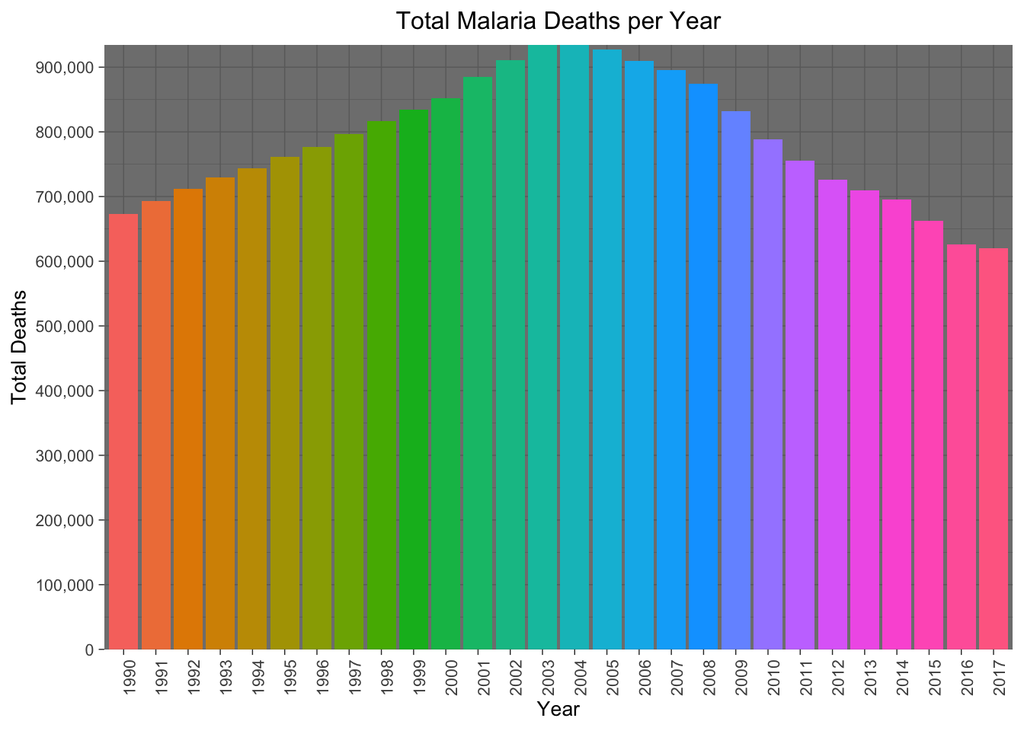

```r
#Making all death counts into numeric values.
malaria.world$total.deaths <- as.numeric(malaria.world$total.deaths)
#Creating bar graph and making aes edits to bar graph.
ggplot(malaria.world, aes(x= year, y= total.deaths, fill = year))+
  theme_dark()+
  geom_bar(stat = "identity")+
  theme(text = element_text(size=10),
        axis.text.x = element_text(angle=90, hjust=1))+
  scale_y_continuous(name="Total Deaths", breaks= seq(0,1500000, by= 100000), labels = comma, expand = c(0, 0))+
  xlab("Year")+
  ggtitle("Total Malaria Deaths per Year")+
  theme(legend.position = "none")+
  theme(plot.title = element_text(hjust = 0.5))
```

*UPDATES FOR VISUAL 2* Hannah Sukhdeo: You mentioned to add percentages to each of the brag graph I don’t think this would be proper for this visual as each graph is a total number of deaths for each year.

*Resources* https://stackoverflow.com/questions/61838700/query-on-how-to-make-world-heat-map-using-ggplot-in-r

https://stackoverflow.com/questions/42683522/r-how-to-sum-a-variable-by-certain-levels-contained-in-a-list-of-another-varia

https://www.youtube.com/watch?v=AgWgPSZ7Gp0

https://stackoverflow.com/questions/13353213/gradient-of-n-colors-ranging-from-color-1-and-color-2

https://stackoverflow.com/questions/60268389/china-not-showing-on-chloropleth-map-in-r

https://www.youtube.com/watch?v=AgWgPSZ7Gp0

https://www.datanovia.com/en/blog/how-to-remove-legend-from-a-ggplot/

https://www.datanovia.com/en/lessons/rename-data-frame-columns-in-r/

http://www.sthda.com/english/wiki/ggplot2-barplots-quick-start-guide-r-software-and-data-visualization

https://www.r-graph-gallery.com/218-basic-barplots-with-ggplot2.html

https://stackoverflow.com/questions/1330989/rotating-and-spacing-axis-labels-in-ggplot2

https://www.datanovia.com/en/blog/how-to-set-ggplot-breaks/

http://www.sthda.com/english/wiki/ggplot2-axis-ticks-a-guide-to-customize-tick-marks-and-labels

https://stackoverflow.com/questions/40675778/center-plot-title-in-ggplot2

https://statisticsglobe.com/change-formatting-of-numbers-of-ggplot2-plot-axis-in-r

https://stackoverflow.com/questions/13701347/force-the-origin-to-start-at-0

https://www.datasciencemadesimple.com/delete-or-drop-rows-in-r-with-conditions-2/

https://stackoverflow.com/questions/56389470/convert-multiple-png-to-gif-as-an-animation-in-r